# Los precios del maíz en México

# Introducción

La ingesta de alimentos nutritivos es el indicador más básico de la calidad de vida y es un factor estratégico fundamental ya que tiene una relación muy importante con el desarrollo de los países a través del desempeño educativo, la productividad y la igualdad de oportunidades, entre otros. Sin embargo, es un fenómeno persistente y a pesar de los acuerdos y acciones llevadas globalmente según la ONU alrededor de 795 millones de personas no disponen de alimentos suficientes para llevar una vida saludable y activa, buena parte de esta población se encuentra en países en desarrollo. Según datos de CONEVAL, en México existen 28 millones de personas que presentan algún nivel de inseguridad alimentaria [1]. Dada la periodicidad de los censos y las encuestas realizadas por el INEGI no podemos hacer un seguimiento constante a esta población. Sin embargo, existen fuentes de datos que nos pueden dar información útil para dar seguimiento a estas poblaciones y poder activar política pública en casos de alerta.

El mercado alimentario mexicano se debe analizar desde el ámbito de la oferta y de la demanda. El seguimiento de la oferta se realiza mediante predicción de producción agrícola y los movimientos de importación y exportación de alimentos en el territorio nacional. Por otro lado, el análisis de la demanda tiene como objetivo principal medir las fuerzas que afectan los requerimientos del mercado con respecto a un bien o servicio dado un nivel de precios.

```r
library(tidyverse)
library(lubridate)
library(stringr)
```

```r
tipo_cambio <-read_csv("data/tipo_de_cambio.csv") %>%
  mutate(fecha = dmy(fecha)) %>%
  mutate(año = year(fecha))  %>%
  mutate(mes = month(fecha)) %>%
  select(año,mes,tipo_cambio)
```

```r
internacional <- read_csv("data/precio_internacional_dolares.csv") %>%
  separate(Month, c("mes", "año"), " ")  %>%
  mutate(año = as.numeric(año))  %>%
  filter(año>2000) %>%
  mutate(mes = match(mes,month.abb))  %>%
  mutate(fecha = make_datetime(year=año, month=mes, day=1)) %>%
  mutate(fecha= ymd(fecha)) %>%
  rename(int_price = Price) %>%
  left_join(tipo_cambio) %>%
  # Obtenemos el precio por kilogramo (De tonelada) por el tipo de cambio
  mutate(int_price = (int_price*tipo_cambio)/1000) %>%
  select(fecha,año,mes,int_price)
```

# Precios nacionales promedio por estado:

```r
nacional <- read_csv("data/precios_granos_semanales.csv")
nacional <- select(nacional,producto,precio_min,fecha,edo_destino,obs) %>%
  mutate(fecha=dmy(fecha)) %>% # tipo de fecha
  mutate(precio_min = ifelse(precio_min > 8, NA, precio_min)) # identificamos un outlier
```

```r
estados_dic <- read_csv("data/estados_dic.csv") %>%
  rename(edo_destino=NOM_ENT) %>%
  mutate(edo_destino = str_to_lower(edo_destino)) %>%
  mutate(CVE_ENT = str_pad(CVE_ENT, 2, pad = "0"))
```

```r
maiz_nacional <- read_csv("data/precios_granos_semanales.csv") %>%
  select(producto,fecha,edo_destino,precio_min,obs) %>%
  #definimos variable de fecha
  mutate(fecha=dmy(fecha)) %>%
  #filtramos el outlier
  filter(precio_min < 15) %>%
  arrange(fecha) %>%
  mutate(mes = month(fecha)) %>%
  mutate(año = year(fecha)) %>%
  mutate(fecha = make_datetime(year=año,month=mes,1)) %>%
  mutate(fecha = ymd (fecha)) %>%
  left_join(estados_dic,by = "edo_destino") %>%
    mutate(CVE_ENT = ifelse(edo_destino== "michoacán", "16",
                          ifelse(edo_destino== "veracruz","30",
                                 ifelse(edo_destino=="df","09",
                                        ifelse(edo_destino=="coahuila","05",CVE_ENT)))))
```

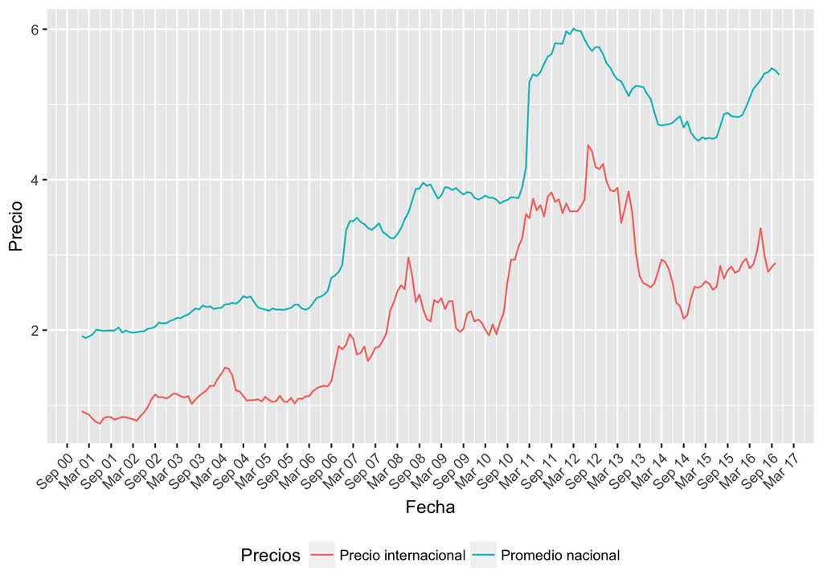

```r
nacional <- maiz_nacional %>%
  group_by(fecha,año,mes) %>%
  summarise(precio_promedio = mean(precio_min, na.rm = TRUE)) %>%
  left_join(internacional,by = c("fecha", "año", "mes"))
nacional_2 <- nacional %>%
  ungroup() %>% as_data_frame() %>%
  select(fecha, precio_promedio, int_price)
colnames(nacional_2) <- c("Fecha","Promedio nacional", "Precio internacional")
nacional_2 <- nacional_2 %>%
  gather(key = Precios, value = Precio, -Fecha) %>%
  filter(!is.na(Precio))
ggplot(nacional_2) +
  geom_line(aes(x = Fecha, y = Precio, color = Precios)) +
  scale_x_date(date_breaks = "6 months", date_labels = "%b %y") +
  theme(legend.position="bottom", axis.text.x = element_text(angle = 45, hjust = 1))
```

# Datos

## PRECIOS NACIONALES

- Información scrappeada del Sistema Nacional de Información e Integración de Mercados (SNIIM)
- Se utiliza precio mínimo por kilogramo (vendido por tonelada)
- Fuente: http://www.economia-sniim.gob.mx/

## MERCADO INTERNACIONAL [Future Market]

- Maize (corn) Monthly Price - US Dollars per Metric Ton
- Fuente: http://www.indexmundi.com/commodities/?commodity=corn&months=240&currency=mxn http://www.indexmundi.com/commodities/?commodity=corn&months=240

## TIPO DE CAMBIO

- Usamos tipo de cambio para hacer comparable el precio de futuros (CF86) - Tipo de cambio promedio del periodo
- Tipo de cambio Pesos por dólar E.U.A., Para solventar obligaciones denominadas en moneda extranjera, Fecha de liquidación Cotizaciones promedio
- Fuente: http://www.banxico.org.mx/SieInternet/consultarDirectorioInternetAction.do?accion=consultarCuadro&idCuadro=CF86

# Bibliografía

- [1] El Universal, En México, 28 millones con con carencia alimentaria. http://www.eluniversal.com.mx/articulo/nacion/sociedad/2016/04/23/en-mexico-28-millones-con-carencia-alimentaria
- [2] Baquedano, Felix G. Developing a price warning indicator as an early warning tool - a compound growth approach. 2015. http://www.fao.org/giews/food-prices/research/detail/es/c/235685/
- [3] CIMMYT. 1994. 1993/94 world maize facts and trends. Mexico, DF.
- http://www.fao.org/giews/food-prices/home/en/
- http://www.fao.org/giews/food-prices/price-warnings/en/ -http://www.fao.org/giews/food-prices/research/detail/es/c/235685/
- Duncan Lee. CARBayes: An R Package for Bayesian Spatial Modeling with Conditional Autoregressive Priors. https://www.jstatsoft.org/article/view/v055i13